# Notes 10: Decision Trees and Random Forests

## Regression Trees for Baseball Data

Suppose we want to predict `Salary` based on `Years` and `Hits` for baseball players. `Salary` is recorded in thousands of dollars; `Year`s is number of years the player has played in the major leagues, and `Hits` is the number of hits the player has made in the previous year.

```r
#  Read in the data

data(Hitters)

hitters <- Hitters |>
  clean_names() |>
  #select(salary, years, hits) |>
  drop_na(salary) |>
  mutate(log_salary = log(salary))

head(hitters)
```

```
                  at_bat hits hm_run runs rbi walks years c_at_bat c_hits
-Alan Ashby          315   81      7   24  38    39    14     3449    835
-Alvin Davis         479  130     18   66  72    76     3     1624    457
-Andre Dawson        496  141     20   65  78    37    11     5628   1575
-Andres Galarraga    321   87     10   39  42    30     2      396    101
-Alfredo Griffin     594  169      4   74  51    35    11     4408   1133
-Al Newman           185   37      1   23   8    21     2      214     42
                  c_hm_run c_runs crbi c_walks league division put_outs assists
-Alan Ashby             69    321  414     375      N        W      632      43
-Alvin Davis            63    224  266     263      A        W      880      82
-Andre Dawson          225    828  838     354      N        E      200      11
-Andres Galarraga       12     48   46      33      N        E      805      40
-Alfredo Griffin        19    501  336     194      A        W      282     421
-Al Newman               1     30    9      24      N        E       76     127
                  errors salary new_league log_salary
-Alan Ashby           10  475.0          N   6.163315
-Alvin Davis          14  480.0          A   6.173786
-Andre Dawson          3  500.0          N   6.214608
-Andres Galarraga      4   91.5          N   4.516339
-Alfredo Griffin      25  750.0          A   6.620073
-Al Newman             7   70.0          A   4.248495
```

```r
str(hitters)
```

```
'data.frame':   263 obs. of  21 variables:
 $ at_bat    : int  315 479 496 321 594 185 298 323 401 574 ...
 $ hits      : int  81 130 141 87 169 37 73 81 92 159 ...
 $ hm_run    : int  7 18 20 10 4 1 0 6 17 21 ...
 $ runs      : int  24 66 65 39 74 23 24 26 49 107 ...
 $ rbi       : int  38 72 78 42 51 8 24 32 66 75 ...
 $ walks     : int  39 76 37 30 35 21 7 8 65 59 ...
 $ years     : int  14 3 11 2 11 2 3 2 13 10 ...
 $ c_at_bat  : int  3449 1624 5628 396 4408 214 509 341 5206 4631 ...
 $ c_hits    : int  835 457 1575 101 1133 42 108 86 1332 1300 ...
 $ c_hm_run  : int  69 63 225 12 19 1 0 6 253 90 ...
 $ c_runs    : int  321 224 828 48 501 30 41 32 784 702 ...
 $ crbi      : int  414 266 838 46 336 9 37 34 890 504 ...
 $ c_walks   : int  375 263 354 33 194 24 12 8 866 488 ...
 $ league    : Factor w/ 2 levels "A","N": 2 1 2 2 1 2 1 2 1 1 ...
 $ division  : Factor w/ 2 levels "E","W": 2 2 1 1 2 1 2 2 1 1 ...
 $ put_outs  : int  632 880 200 805 282 76 121 143 0 238 ...
 $ assists   : int  43 82 11 40 421 127 283 290 0 445 ...
 $ errors    : int  10 14 3 4 25 7 9 19 0 22 ...
 $ salary    : num  475 480 500 91.5 750 ...
 $ new_league: Factor w/ 2 levels "A","N": 2 1 2 2 1 1 1 2 1 1 ...
 $ log_salary: num  6.16 6.17 6.21 4.52 6.62 ...
```

```r
#fit the decision tree (regression tree)
fit_reg_tree <- tree(log_salary ~ years + hits, data = hitters)
fit_reg_tree
```

```
node), split, n, deviance, yval
      * denotes terminal node

 1) root 263 207.200 5.927
   2) years < 4.5 90  42.350 5.107
     4) years < 3.5 62  23.010 4.892
       8) hits < 114 43  17.150 4.727
        16) hits < 40.5 5  10.400 5.511 *
        17) hits > 40.5 38   3.280 4.624 *
       9) hits > 114 19   2.069 5.264 *
     5) years > 3.5 28  10.130 5.583 *
   3) years > 4.5 173  72.710 6.354
     6) hits < 117.5 90  28.090 5.998
      12) years < 6.5 26   7.238 5.689 *
      13) years > 6.5 64  17.350 6.124
        26) hits < 50.5 12   2.689 5.730 *
        27) hits > 50.5 52  12.370 6.215 *
     7) hits > 117.5 83  20.880 6.740 *
```

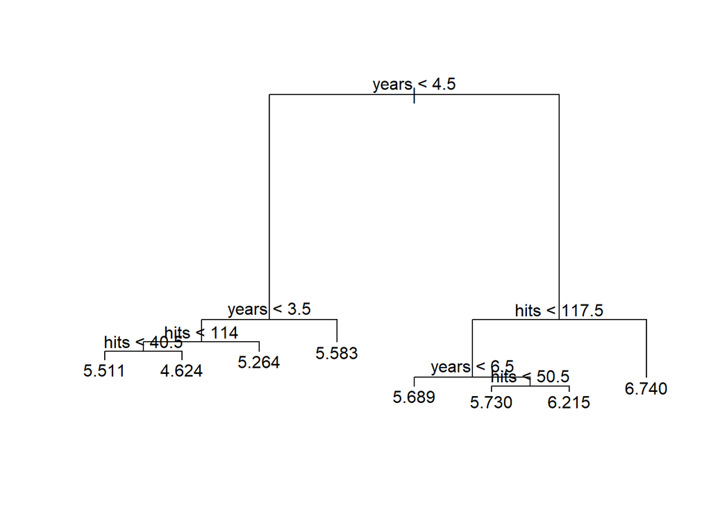

```r
#Graph the regression tree
plot(fit_reg_tree)
text(fit_reg_tree, pretty = 0) #pretty=0 just tells R to print factor names directly instead of giving them code letters
```

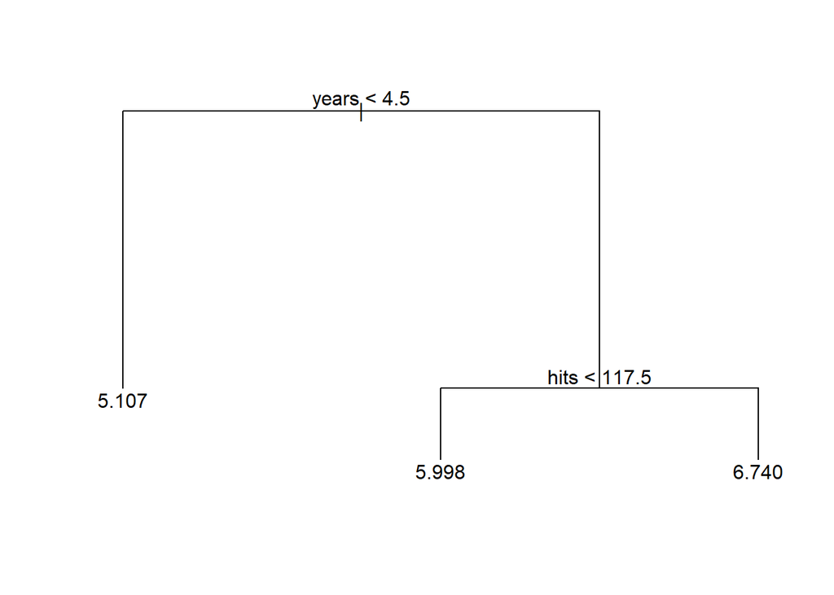

```r
#Prune the tree to 3 terminal nodes
prune_salary <- prune.tree(fit_reg_tree, best = 3)
plot(prune_salary)
text(prune_salary, pretty = 0)
```

Keep in mind that we log transformed salary, so the predictions from the tree are on the log scale. To get predictions on the original scale, we need to exponentiate the final leaves to understand the predictions. Each of these values represents thousands of dollars.

```r
#Exponentiate leaves
exp(5.107)
```

```
[1] 165.1741
```

```r
exp(5.998)
```

```
[1] 402.6227
```

```r
exp(6.740)
```

```
[1] 845.5607
```

## Other packages

Note there are other packages that also fit decision trees, such as `rpart`. Used with the `partykit` package, it can make some nicer diagrams, but results do not perfectly match the `tree` package. Here is an examplew with the baseball data.

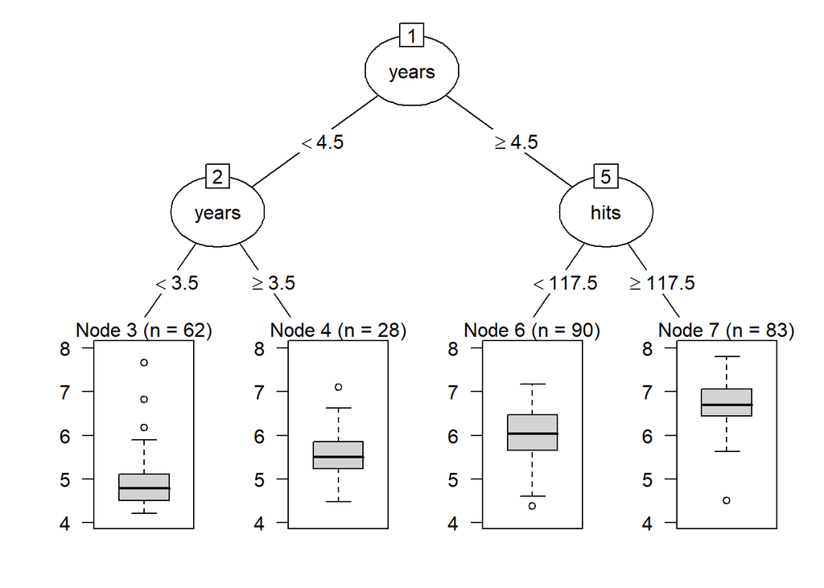

```r
library(rpart)
library(partykit)
fit <- rpart(log_salary ~ years + hits,
             data = hitters,
             control = rpart.control(maxdepth = 2))
plot(as.party(fit))
```

## Linear Model Approach

Allowing for an interaction term between years and hits as well.

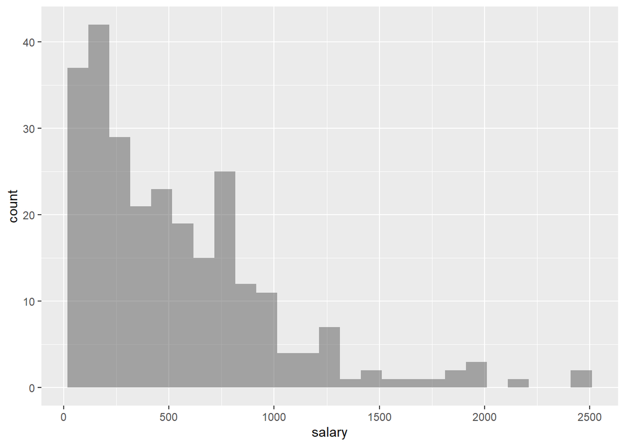

```r
#exploratory analysis
gf_histogram(~salary, data = hitters)
```

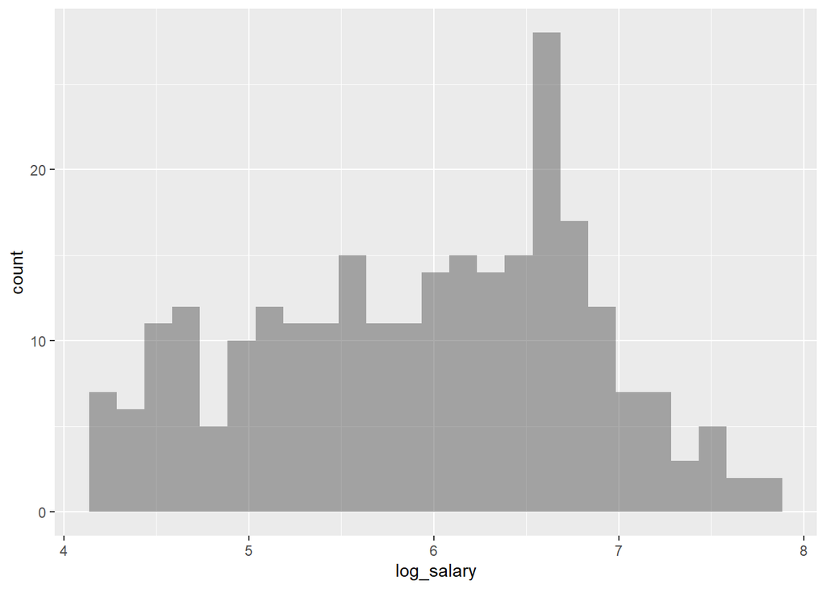

```r
#log transform
gf_histogram(~log_salary, data = hitters)
```

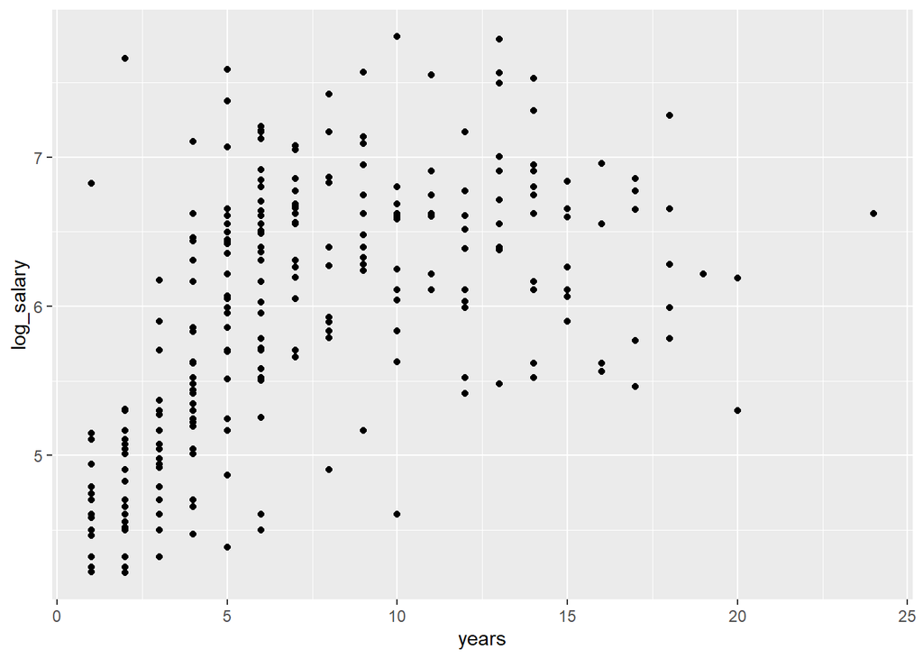

```r
#scatterplots of salary by x variables
gf_point(log_salary ~ years, data = hitters)
```

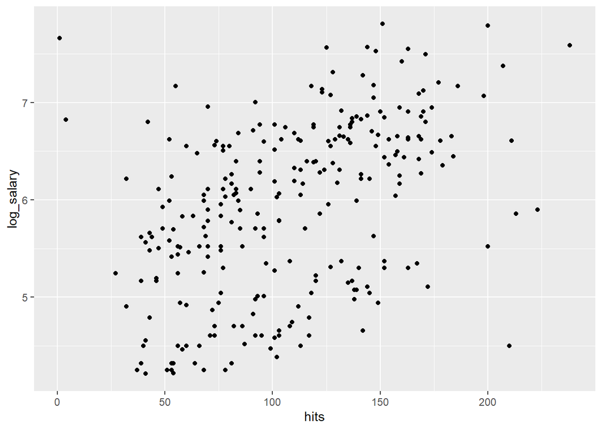

```r
gf_point(log_salary ~ hits, data = hitters)
```

```r
salary_model <- lm(log_salary ~ years + hits + years*hits, data = hitters)
summary(salary_model)
```

```
Call:
lm(formula = log_salary ~ years + hits + years * hits, data = hitters)

Residuals:
     Min       1Q   Median       3Q      Max
-2.13711 -0.50308  0.03298  0.42883  2.97453

Coefficients:
             Estimate Std. Error t value Pr(>|t|)
(Intercept) 4.5734694  0.1742141  26.252  < 2e-16 ***
years       0.0540705  0.0207183   2.610 0.009587 **
hits        0.0055808  0.0015910   3.508 0.000533 ***
years:hits  0.0004501  0.0001942   2.318 0.021228 *
---
Signif. codes:  0 '***' 0.001 '**' 0.01 '*' 0.05 '.' 0.1 ' ' 1

Residual standard error: 0.637 on 259 degrees of freedom
Multiple R-squared:  0.4926,    Adjusted R-squared:  0.4867
F-statistic: 83.82 on 3 and 259 DF,  p-value: < 2.2e-16
```

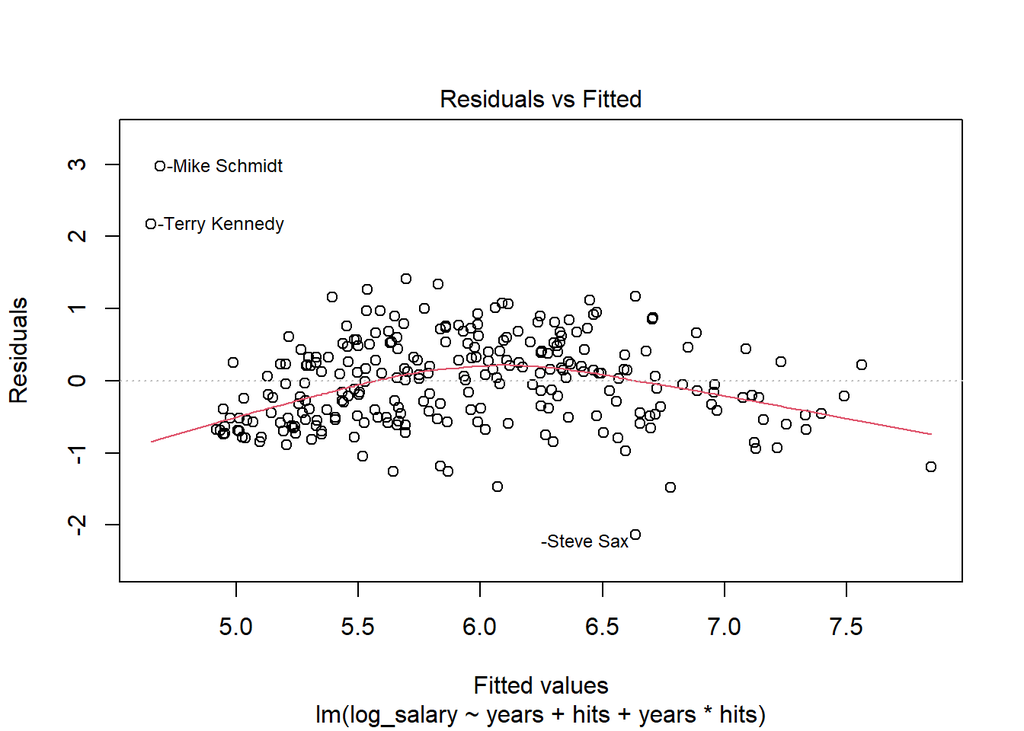

```r
#check assumptions
plot(salary_model, 1) #resids vs fitted
```

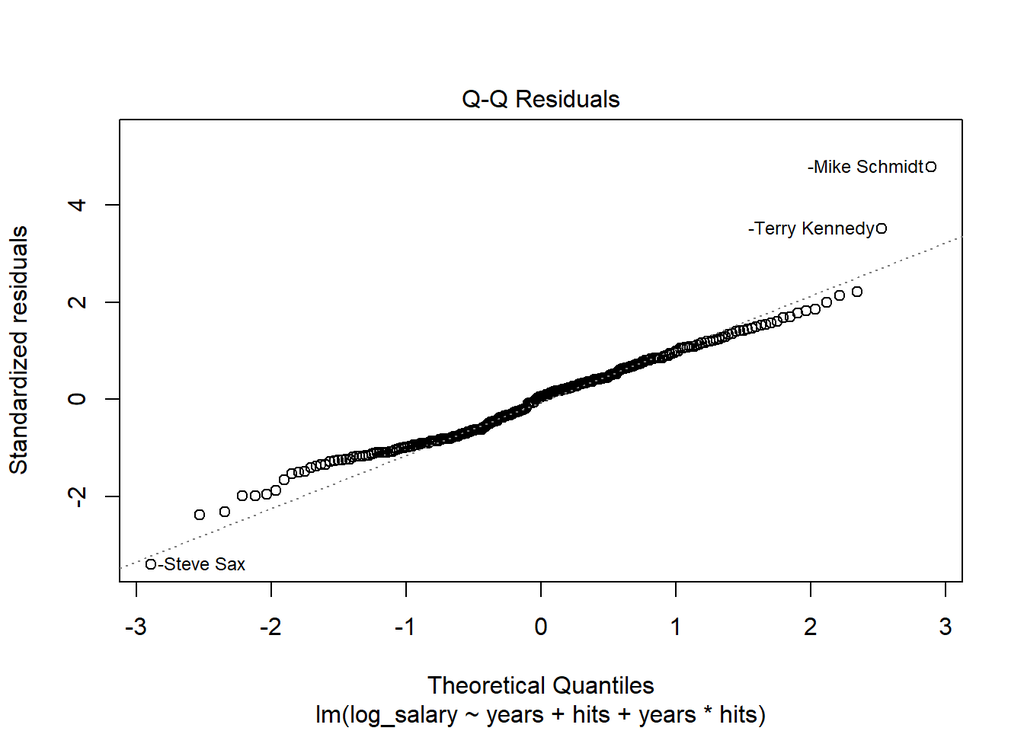

```r
plot(salary_model, 2) #qq
```

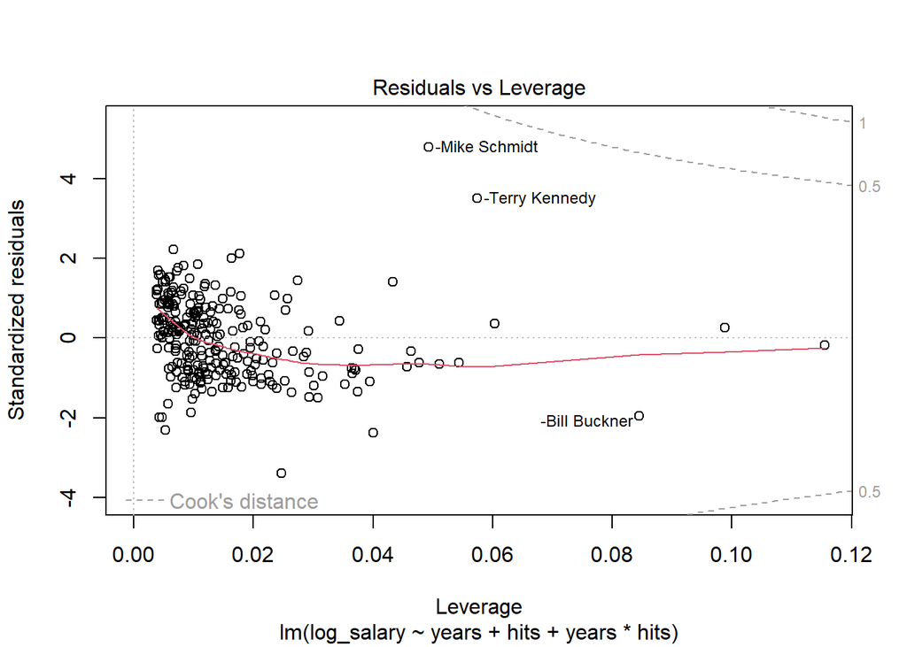

```r
plot(salary_model, 5) #cooks distance
```

```r
#log-linear model so to get predictions on the original scale, we need to exponentiate the predictions from the model
exp(coef(salary_model))
```

```
(Intercept)       years        hits  years:hits
  96.879646    1.055559    1.005596    1.000450
```

## Cross-Validation and Pruning

Normally when fitting a decision tree, it is best practice to train the model first and then use cross-validation for pruning, then fit to test data.

First we show a large regression tree with multiple predictors for log_salary.

```r
#fit the decision tree (regression tree)
hitters_nosal <- hitters |>
  select(log_salary, years, rbi, put_outs, hits, walks, runs)

#split the data into training and testing (just 50/50)
set.seed(410)
train <- sample(1:nrow(hitters_nosal), nrow(hitters_nosal)/2)
#hitters_test will be used later for the random forest
hitters_test <- hitters_nosal[-train, "log_salary"]

#fit a regression tree on the training data. Results will not perfectly match the reading because we randomly split the data in a different way!
fit_reg_tree_large <- tree(log_salary ~ ., data = hitters_nosal, subset = train)
fit_reg_tree_large
```

```
node), split, n, deviance, yval
      * denotes terminal node

 1) root 131 116.40000 5.984
   2) years < 4.5 46  28.18000 5.142
     4) years < 3.5 32  16.76000 4.914
       8) walks < 15.5 5  10.47000 5.505 *
       9) walks > 15.5 27   4.22500 4.805
        18) hits < 80 8   0.07338 4.328 *
        19) hits > 80 19   1.56100 5.006 *
     5) years > 3.5 14   5.96400 5.663
      10) walks < 32.5 7   0.78400 5.176 *
      11) walks > 32.5 7   1.85700 6.150 *
   3) years > 4.5 85  37.99000 6.439
     6) hits < 103.5 36  11.72000 6.011
      12) walks < 44 28   6.90900 5.850 *
      13) walks > 44 8   1.55600 6.574 *
     7) hits > 103.5 49  14.82000 6.754
      14) rbi < 80 33   8.40400 6.564
        28) years < 6.5 14   4.23000 6.283
          56) rbi < 59 6   2.76000 5.949 *
          57) rbi > 59 8   0.29990 6.533 *
        29) years > 6.5 19   2.25300 6.771 *
      15) rbi > 80 16   2.78300 7.145 *
```

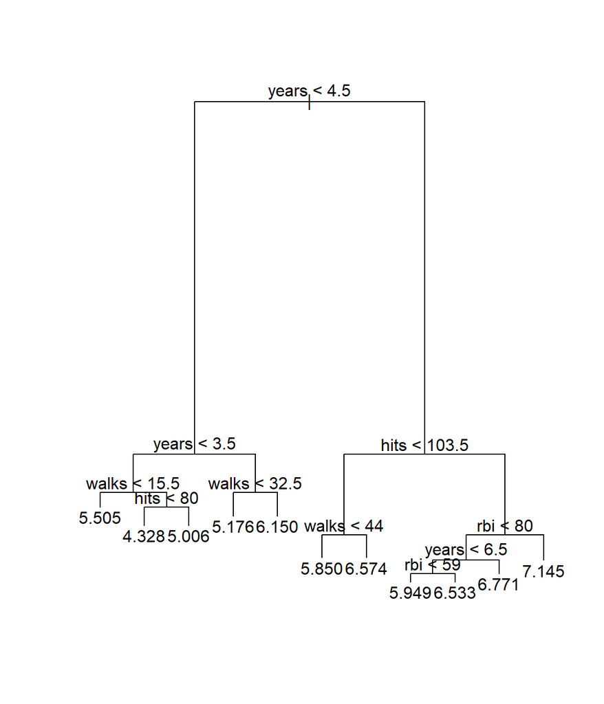

```r
#Graph the regression tree
plot(fit_reg_tree_large)
text(fit_reg_tree_large, pretty = 0)
```

Cross-validation for pruning: We will still use the baseball data.

```r
cv_hitters <- cv.tree(fit_reg_tree_large)

#smallest deviance is desirable: size 7 means 7 terminal nodes are suggested from this analysis.
cv_hitters
```

```
$size
 [1] 11 10  9  7  6  5  4  3  2  1

$dev
 [1]  59.68147  59.72732  59.27268  56.57027  61.47769  61.47769  61.14080
 [8]  70.46998  74.05959 117.59346

$k
 [1]      -Inf  1.169692  1.922022  2.328027  3.260047  3.323606  3.632474
 [8]  5.457829 11.448881 50.205779

$method
[1] "deviance"

attr(,"class")
[1] "prune"         "tree.sequence"
```

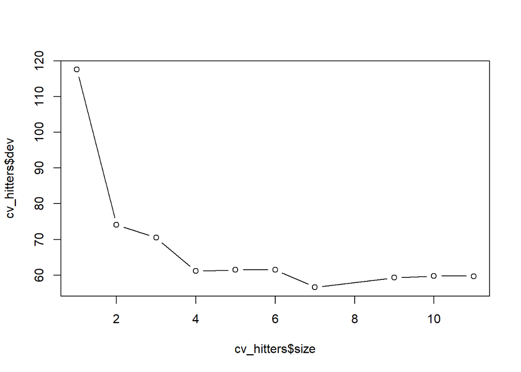

```r
plot(cv_hitters$size, cv_hitters$dev, type = "b")
```

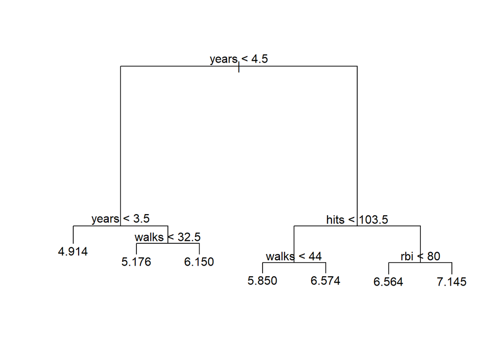

```r
#now prune to 7 terminal nodes
prune_hitters <- prune.tree(fit_reg_tree_large, best = 7)
plot(prune_hitters)
text(prune_hitters, pretty = 0)
```

## Random Forest Model

### Fit the Model

```r
library(randomForest)

set.seed(411)

#the "." in the model below says to consider all possible predictors in the model, rather than specifying predictors to use
#mtry should be about the square root of the number of predictors. here we have 6 predictors; we will consider 3 for each model
rf_hitters <- randomForest(log_salary ~ ., mtry = 3, data = hitters_nosal, subset = train, importance = TRUE, na.action = na.omit)
rf_hitters
```

```
Call:
 randomForest(formula = log_salary ~ ., data = hitters_nosal,      mtry = 3, importance = TRUE, subset = train, na.action = na.omit)
               Type of random forest: regression
                     Number of trees: 500
No. of variables tried at each split: 3

          Mean of squared residuals: 0.2917208
                    % Var explained: 67.16
```

### Predictions from Random Forest

Now we predict with the test data

```r
#yh_rf is the predicted log salary from each player. How could we get predicted salaries?
yhat_rf <- predict(rf_hitters, newdata = hitters_nosal[-train, ])

exp(yhat_rf)
```

```
     -Alvin Davis     -Andre Dawson -Andres Galarraga  -Argenis Salazar
        284.28428         841.50170         132.64133         102.10954
   -Alan Trammell     -Alan Wiggins       -Bill Almon       -Buddy Bell
        795.41699         296.80000         372.12444         897.16344
   -Bobby Bonilla     -Bill Buckner     -Brett Butler      -Bob Dernier
        142.94460        1374.22441         563.00745         299.02105
         -Bo Diaz    -Brian Downing    -Billy Hatcher     -Brook Jacoby
        819.07653        1058.41321         135.78183         712.96030
     -Bob Kearney      -Chris Brown  -Carmen Castillo     -Carlton Fisk
        301.20764         163.00026         276.85563         516.58303
       -Curt Ford  -Carney Lansford   -Craig Reynolds    -Dave Anderson
         81.86861         743.00671         328.88480         202.08872
   -Darnell Coles    -Doug DeCinces    -Damaso Garcia      -Dan Gladden
        567.02945         926.56073         341.14297         264.47774
     -Davey Lopes      -Dale Murphy    -Dwayne Murphy  -Danny Tartabull
        421.49339        1092.26923         511.29857         229.90769
   -Denny Walling     -Eddie Milner        -Ed Romero      -Frank White
        659.99363         532.75029         269.12444         945.86894
     -George Bell     -Glenn Braggs     -George Brett      -Glenn Davis
        949.60654          81.45706         982.47580         256.44036
 -George Hendrick    -Glenn Hubbard       -Garth Iorg    -Graig Nettles
        442.90132         570.13301         302.04399         578.34365
      -Gary Redus  -Garry Templeton      -Greg Walker        -Gary Ward
        374.24567         573.23368         450.96139         554.27465
    -Glenn Wilson   -Howard Johnson        -Hal McRae    -Harry Spilman
        785.55902         310.18442         307.79202         333.96170
 -Herm Winningham    -Juan Beniquez   -John Cangelosi       -Joe Carter
         93.85634         399.75550         152.10325         520.15578
     -Jim Gantner      -Jack Howell        -John Kruk     -Jim Morrison
        533.92025          79.55198         104.86540         950.85100
      -John Moses   -Jerry Mumphrey      -Jim Presley        -Jeff Reed
        325.33928         382.91276         206.44863         103.62482
    -John Russell      -Juan Samuel      -John Shelby     -Joel Skinner
        140.96491         396.05493         304.57482         194.60390
 -Joel Youngblood      -Kirk Gibson      -Ken Griffey  -Keith Hernandez
        352.77121         725.37797         775.86646        1373.84423
      -Ken Phelps    -Kirby Puckett      -Len Dykstra    -Larry Herndon
        762.54344         245.18804         159.72245         396.09321
        -Lee Lacy     -Len Matuszek    -Lance Parrish    -Larry Parrish
        685.16219         262.14731         619.96133         944.66156
```

[output cut: 11 more lines]

```
        576.98232         746.43343         511.66852         847.76784
    -Rey Quinones   -Rafael Ramirez     -Ron Roenicke    -Ryne Sandberg
         82.23737         274.57446         444.30382         698.84241
  -Rafael Santana        -Rick Schu     -Ruben Sierra      -Rob Wilfong
        257.20462         103.98651         123.02738         342.44543
     -Robin Yount    -Steve Balboni    -Scott Bradley        -Sid Bream
        703.77688         837.08895          99.40137         604.50329
     -Steve Jeltz     -Tom Brookens    -Tom Brunansky   -Tony Fernandez
        300.59895         288.74381         714.67107         278.92928
       -Tom Foley       -Tony Gwynn     -Terry Harper       -Tommy Herr
        193.39887         343.50062         334.37845         887.77415
    -Tito Landrum      -Tim Laudner       -Tim Teufel        -Von Hayes
        262.01976         307.04757         229.70980        1428.93222
       -Vance Law    -Wally Backman       -Wade Boggs   -Wayne Tolleson
        428.67159         489.45561         543.72665         496.50649
```

```r
#calculate SSE
mean((yhat_rf - hitters_test)^2)
```

```
[1] 0.2532742
```

### Variable Importance

```r
importance(rf_hitters)
```

```
           %IncMSE IncNodePurity
years    62.121690     46.387692
rbi      15.403780     20.078856
put_outs  2.825133      6.514489
hits      6.754328     15.060772
walks    14.568746     15.400864
runs      9.417185      8.633961
```

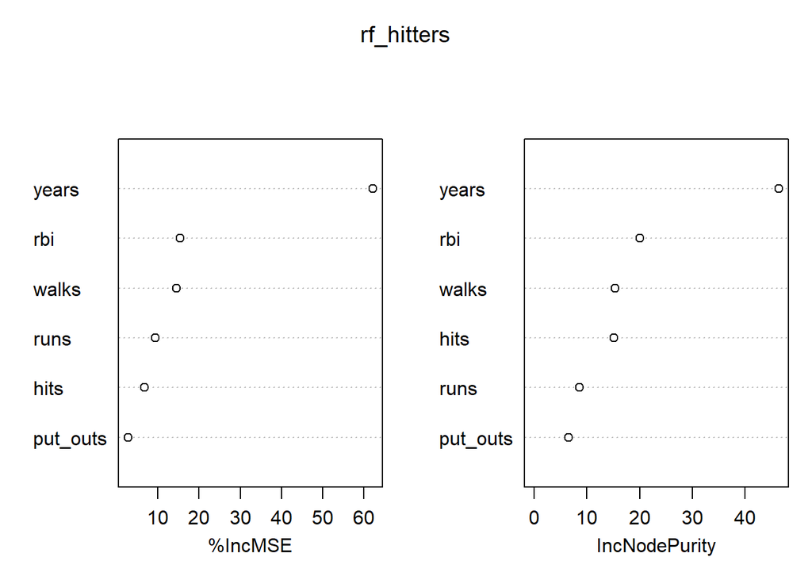

```r
varImpPlot(rf_hitters)
```